# US_Mass_shootings

Aditi Deokar

1/10/2020

## DATASET DESCRIPTION

### Source-

- https://www.motherjones.com/politics/2012/12/mass-shootings-mother-jones-full-data/

### Background-

- Since 1982, there have been at least 117 public mass shootings across the country, with the killings unfolding in 35 states, from Massachusetts to Hawaii.
- They are occurring more often: An analysis of this database by researchers at Harvard University, further corroborated by a different study from the FBI, determined that mass shootings have tripled in frequency in recent years.

### Characteristics-

- Number of categorical data columns:18
- Number of numerical data columns:6

### Reference-

- https://www.kaggle.com/denisafonin/data-cleaning-and-dealing-with-missing-values/#data

### IMPORT LIBRARIES

```r
library(tibble)
library(lubridate)
library(tidyr)
library(stringr)
library(ggmap)
library(RColorBrewer)
```

### IMPORT DATA

```r
  mass_shootings<-read.csv("Assignment1-Deokar-US_Mass_Shootings.csv", stringsAsFactors = FALSE)
```

### EXPLORE DATA

```r
glimpse(mass_shootings)
```

```
## Observations: 117
## Variables: 24
## $ case                             <chr> "Jersey City kosher market sh...
## $ location                         <chr> "Jersey City, New Jersey", "P...
## $ date                             <chr> "12/10/19", "12/6/19", "8/31/...
## $ summary                          <chr> "David N. Anderson, 47, and F...
## $ fatalities                       <int> 4, 3, 7, 9, 22, 3, 12, 5, 3, ...
## $ injured                          <int> 3, 8, 25, 27, 26, 12, 4, 6, 1...
## $ total_victims                    <int> 7, 11, 32, 36, 48, 15, 16, 11...
## $ location.1                       <chr> "Other", "Military", "Other",...
## $ age_of_shooter                   <chr> "-", "-", "36", "24", "21", "...
## $ prior_signs_mental_health_issues <chr> "-", "-", "yes", "-", "-", "T...
## $ mental_health_details            <chr> "-", "-", "\"One friend of th...
## $ weapons_obtained_legally         <chr> "-", "-", "-", "Yes", "Yes", ...
## $ where_obtained                   <chr> "-", "-", "-", "-", "-", "Nev...
## $ weapon_type                      <chr> "-", "semiautomatic handgun",...
## $ weapon_details                   <chr> "-", "-", "-", "AR-15-style r...
## $ race                             <chr> "Black", "-", "White", "White...
## $ gender                           <chr> "-", "M", "M", "M", "M", "M",...
## $ sources                          <chr> "https://www.nytimes.com/2019...
## $ mental_health_sources            <chr> "-", "-", "https://www.nytime...
## $ sources_additional_age           <chr> "-", "-", "-", "-", "-", "-",...
## $ latitude                         <dbl> 40.70736, 30.36471, 31.92597,...
## $ longitude                        <dbl> -74.08361, -87.28857, -102.27...
## $ type                             <chr> "Spree", "Mass", "Spree", "Ma...
## $ year                             <int> 2019, 2019, 2019, 2019, 2019,...
```

```r
summary(mass_shootings) #displays summary statistics for numeric variables
```

```
##      case             location             date
##  Length:117         Length:117         Length:117
##  Class :character   Class :character   Class :character
##  Mode  :character   Mode  :character   Mode  :character
##
##
##
##    summary            fatalities        injured       total_victims
##  Length:117         Min.   : 3.000   Min.   :  0.00   Min.   :  3.00
##  Class :character   1st Qu.: 5.000   1st Qu.:  1.00   1st Qu.:  7.00
##  Mode  :character   Median : 6.000   Median :  4.00   Median : 11.00
##                     Mean   : 8.103   Mean   : 12.33   Mean   : 20.44
##                     3rd Qu.: 9.000   3rd Qu.: 11.00   3rd Qu.: 18.00
##                     Max.   :58.000   Max.   :546.00   Max.   :604.00
##   location.1        age_of_shooter     prior_signs_mental_health_issues
##  Length:117         Length:117         Length:117
##  Class :character   Class :character   Class :character
##  Mode  :character   Mode  :character   Mode  :character
##
##
##
##  mental_health_details weapons_obtained_legally where_obtained
##  Length:117            Length:117               Length:117
##  Class :character      Class :character         Class :character
##  Mode  :character      Mode  :character         Mode  :character
##
##
##
##  weapon_type        weapon_details         race
##  Length:117         Length:117         Length:117
##  Class :character   Class :character   Class :character
##  Mode  :character   Mode  :character   Mode  :character
##
##
##
##     gender            sources          mental_health_sources
##  Length:117         Length:117         Length:117
##  Class :character   Class :character   Class :character
##  Mode  :character   Mode  :character   Mode  :character
##
##
##
##  sources_additional_age    latitude       longitude
##  Length:117             Min.   :21.32   Min.   :-157.88
##  Class :character       1st Qu.:33.56   1st Qu.:-117.28
##  Mode  :character       Median :38.25   Median : -90.67
##                         Mean   :37.30   Mean   : -96.58
##                         3rd Qu.:41.49   3rd Qu.: -81.29
##                         Max.   :48.46   Max.   : -71.08
##      type                year
##  Length:117         Min.   :1982
##  Class :character   1st Qu.:1999
##  Mode  :character   Median :2012
##                     Mean   :2008
##                     3rd Qu.:2017
##                     Max.   :2019
```

### *Obervations:*

- Date, age_of_shooter variable’s class is to be transformed to correct data type
- Total victims: There is a strange distribution - Max is huge compared to the 3rd quartile. Mean is 2 times higher than median which implies that the distribution is skewed towards the upper limit.
- Fatalities and Injured variables are the subsets of Total victims variable and have the same issue.

## CLEANING DATA

### *Untidy data:*

- The dataset has a column named “location” which contains the “City” and “State” together separated by “,” where the shootings have taken place. This indicates an untidy data since cities and states should have different columns in order to see the distribution of mass shootings over cities or states.
- To convert this untidy data to tidy data, we need to separate “Location” column into two different columns named “City” and “State”

### *Separating Location to “City” and “State”:*

```r
head(mass_shootings$location, n=20)
```

```
##  [1] "Jersey City, New Jersey"     "Pensacola, Florida"
##  [3] "Odessa, Texas"               "Dayton, Ohio"
##  [5] "El Paso, Texas"              "Gilroy, California"
##  [7] "Virginia Beach, Virginia"    "Aurora, Illinois"
##  [9] "State College, Pennsylvania" "Sebring, Florida"
## [11] "Chicago, Illinois"           "Thousand Oaks, California"
## [13] "Pittsburgh, Pennsylvania"    "Perryman, Maryland"
## [15] "Bakersfield, California"     "Cincinnati, Ohio"
## [17] "Annapolis, Maryland"         "Santa Fe, Texas"
## [19] "Nashville, Tennessee"        "Yountville, California"
```

```r
mass_shootings <- separate(mass_shootings, location, c("City", "State"), sep = ",", remove=FALSE)

#erase blank spaces from the beginning and end of each state name
mass_shootings$State<-str_trim(mass_shootings$State)
```

### *Tidy Data:*

```r
my_data <- as_tibble(mass_shootings)
#my_data %>% select(location:State)
my_data %>% dplyr::select(location:State)
```

```
## # A tibble: 117 x 3
##    location                    City           State
##    <chr>                       <chr>          <chr>
##  1 Jersey City, New Jersey     Jersey City    New Jersey
##  2 Pensacola, Florida          Pensacola      Florida
##  3 Odessa, Texas               Odessa         Texas
##  4 Dayton, Ohio                Dayton         Ohio
##  5 El Paso, Texas              El Paso        Texas
##  6 Gilroy, California          Gilroy         California
##  7 Virginia Beach, Virginia    Virginia Beach Virginia
##  8 Aurora, Illinois            Aurora         Illinois
##  9 State College, Pennsylvania State College  Pennsylvania
## 10 Sebring, Florida            Sebring        Florida
## # ... with 107 more rows
```

### *Changing multiple column names*

```r
colnames(mass_shootings)[colnames(mass_shootings) %in% c("age_of_shooter","location.1","prior_signs_mental_health_issues")] <- c("age", "type_of_location","mental_health_issues")

#summary(mass_shootings)
```

### *Changing Date variable to date type*

```r
mass_shootings$date<-mdy(mass_shootings$date)
```

### *Changing Age variable to numeric type*

```r
mass_shootings$age<-as.numeric(mass_shootings$age,message=FALSE, warning=FALSE)
#summary(mass_shootings)
```

### *Changing “mental_health_issues”, “race”, “gender” columns’ classes to factors*

```r
cols_to_factors<-c("mental_health_issues", "race", "gender")
mass_shootings[,cols_to_factors]<-lapply(mass_shootings[,cols_to_factors], as.factor)
```

### *Standardize levels for “gender”, “race” and “mental_health_issues”:*

### *Gender:*

```r
levels(mass_shootings$gender)
```

```
## [1] "-"             "F"             "Female"        "M"
## [5] "Male"          "Male & Female"
```

```r
levels(mass_shootings$gender)[levels(mass_shootings$gender)=="M"] <- "Male"
levels(mass_shootings$gender)[levels(mass_shootings$gender)=="F"] <- "Female"
levels(mass_shootings$gender)[levels(mass_shootings$gender)=="Male & Female"] <- "Male/Female"
levels(mass_shootings$gender)[levels(mass_shootings$gender)=="-"] <- "Unknown"

levels(mass_shootings$gender)
```

```
## [1] "Unknown"     "Female"      "Male"        "Male/Female"
```

```r
table(mass_shootings$gender)
```

```
##
##     Unknown      Female        Male Male/Female
##           1           3         112           1
```

```r
nlevels(mass_shootings$gender)
```

```
## [1] 4
```

```r
sum(table(mass_shootings$gender))==nrow(mass_shootings)
```

```
## [1] TRUE
```

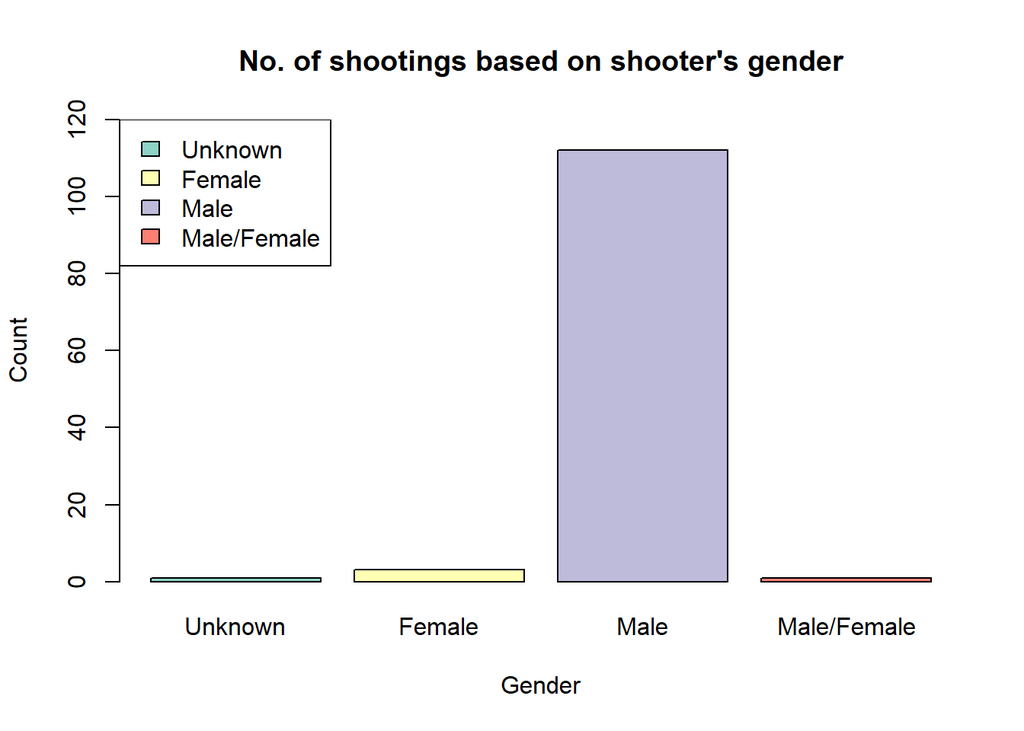

```r
#plot(mass_shootings$gender,ylim = c(0,140))
coul <- brewer.pal(4, "Set3")
barplot(table(mass_shootings$gender),
main="No. of shootings based on shooter's gender",
xlab="Gender",
ylab="Count",ylim = c(0,120),
col = coul
)
legend("topleft",
c("Unknown","Female","Male","Male/Female"),
fill = coul
)
```

### *Observations-*

- The above graph shows that male shooters were responsible for majority of the mass shootings(i.e. 95% of the shootings)

### *Race:*

```r
levels(mass_shootings$race)
```

```
##  [1] "-"               "Asian"           "black"
##  [4] "Black"           "Latino"          "Native American"
##  [7] "Other"           "unclear"         "white"
## [10] "White"           "White "
```

```r
levels(mass_shootings$race)[levels(mass_shootings$race)=="-"]<-"Unknown"
levels(mass_shootings$race)[levels(mass_shootings$race)=="black"
                            |levels(mass_shootings$race)=="Black"]<-"Black American"
levels(mass_shootings$race)[levels(mass_shootings$race)=="white"
                            |levels(mass_shootings$race)=="white"
                            |levels(mass_shootings$race)=="White"
                            |levels(mass_shootings$race)=="White "]<-"White American"
levels(mass_shootings$race)[levels(mass_shootings$race)=="unclear"]<-"Unknown"
levels(mass_shootings$race)[levels(mass_shootings$race)=="Native American"]<-"Native American"

table(mass_shootings$race)
```

```
##
##         Unknown           Asian  Black American          Latino
##               6               8              20              10
## Native American           Other  White American
##               3               5              65
```

### *Mental Health Issues:*

```r
levels(mass_shootings$mental_health_issues)
```

```
## [1] "-"        "No"       "TBD"      "Unclear"  "Unclear " "Unknown"
## [7] "yes"      "Yes"
```

```r
levels(mass_shootings$mental_health_issues)[levels(mass_shootings$mental_health_issues)=="Unclear " |levels(mass_shootings$mental_health_issues)=="Unclear"   |levels(mass_shootings$mental_health_issues)=="unknown" | levels(mass_shootings$mental_health_issues)=="-"]<-"Unknown"

levels(mass_shootings$mental_health_issues)[levels(mass_shootings$mental_health_issues)=="yes"
                            |levels(mass_shootings$mental_health_issues)=="Yes"]<-"Yes"

levels(mass_shootings$mental_health_issues)
```

```
## [1] "Unknown" "No"      "TBD"     "Yes"
```

```r
table(mass_shootings$mental_health_issues)
```

```
##
## Unknown      No     TBD     Yes
##      36      17       5      59
```

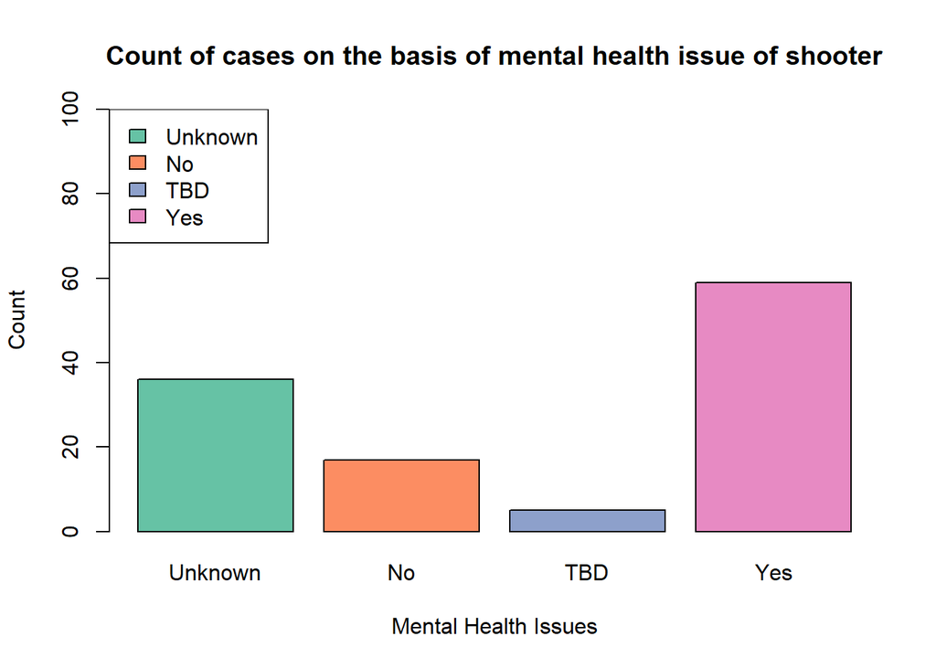

```r
#plot(mass_shootings$mental_health_issues,ylim = c(0,70))
library(RColorBrewer)
coul <- brewer.pal(4, "Set2")
barplot(table(mass_shootings$mental_health_issues),
main="Count of cases on the basis of mental health issue of shooter",
xlab="Mental Health Issues",
ylab="Count",ylim = c(0,100),
col = coul
)
legend("topleft",
c("Unknown","No","TBD","Yes"),
fill = coul)
```

### *Observations-*

- The above graph shows that more than 50% of the shooters suffered through mental health issues.

## *Standardize State names:*

```r
mass_shootings$State<-as.factor(mass_shootings$State)
levels(mass_shootings$State)
```

```
##  [1] "Arizona"        "Arkansas"       "California"     "Colorado"
##  [5] "Connecticut"    "D.C."           "Florida"        "Georgia"
##  [9] "Hawaii"         "Illinois"       "Iowa"           "Kansas"
## [13] "Kentucky"       "Lousiana"       "Maryland"       "Massachusetts"
## [17] "Michigan"       "Minnesota"      "Mississippi"    "Missouri"
## [21] "Nebraska"       "Nevada"         "New Jersey"     "New York"
## [25] "North Carolina" "Ohio"           "Oklahoma"       "Oregon"
## [29] "Pennsylvania"   "South Carolina" "Tennessee"      "Texas"
## [33] "Utah"           "Virginia"       "Washington"     "Wisconsin"
```

```r
#Creating a data frame of all states with abbreviations:
st.codes<-data.frame(
  state=(c("AK", "AL", "AR", "AZ", "CA", "CO", "CT", "DC", "DE", "FL", "GA",
                    "HI", "IA", "ID", "IL", "IN", "KS", "KY", "LA", "MA", "MD", "ME",
                    "MI", "MN", "MO", "MS",  "MT", "NC", "ND", "NE", "NH", "NJ", "NM",
                    "NV", "NY", "OH", "OK", "OR", "PA", "PR", "RI", "SC", "SD", "TN",
                    "TX", "UT", "VA", "VT", "WA", "WI", "WV", "WY")),
  full=(c("alaska","alabama","arkansas","arizona","california","colorado",
                   "connecticut","district of columbia","delaware","florida","georgia",
                   "hawaii","iowa","idaho","illinois","indiana","kansas","kentucky",
                   "louisiana","massachusetts","maryland","maine","michigan","minnesota",
                   "missouri","mississippi","montana","north carolina","north dakota",
                   "nebraska","new hampshire","new jersey","new mexico","nevada",
                   "new york","ohio","oklahoma","oregon","pennsylvania","puerto rico",
                   "rhode island","south carolina","south dakota","tennessee","texas",
                   "utah","virginia","vermont","washington","wisconsin",
                   "west virginia","wyoming")), stringsAsFactors = FALSE)

# Standardizing state names using the data frame "st.codes":
matched_states<-match(mass_shootings$State, st.codes$state)

mass_shootings[which(!is.na(matched_states)), "State"]<-st.codes$full[match(mass_shootings$State[which(!is.na(matched_states))], st.codes$state)]
mass_shootings$State<-tolower(mass_shootings$State)

#Adding the State Abbreviation column:
mass_shootings$State_Abbr <- sapply(mass_shootings$State, function(x) st.codes$state[match(x, st.codes$full)])

mass_shootings[,c("State", "State_Abbr")]<-lapply(mass_shootings[,c("State", "State_Abbr")], as.factor)
```

### *Plotting the distribution of shootings over the years in various states according to shooting type*

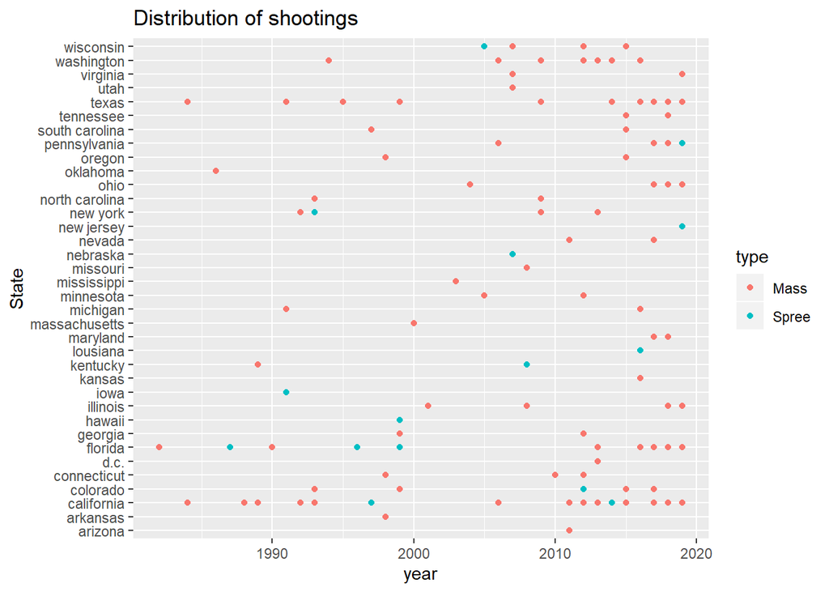

```r
ggplot(data = mass_shootings) +
geom_point(mapping = aes(x = year, y = State, color = type))+
  labs(title="Distribution of shootings")
```

### *Observations-*

- The above scatter plot shows that the number of mass shootings in USA increased over the last decade in states like California, Colorado, Florida, Texas, Washington, Ohio.